# Sales case

CRJR

This RMD is divided in:

- Data discovery
- Data transformation and clusters
- Sales forecasting

This data contains sales information from a company. The aim of this exercise is to understand it and to provide a forecast for december 2017.

# Data discovery

```r
first(as.Date(data$date))
```

```
## [1] "2016-12-01"
```

```r
last(as.Date(data$date))
```

```
## [1] "2017-12-31"
```

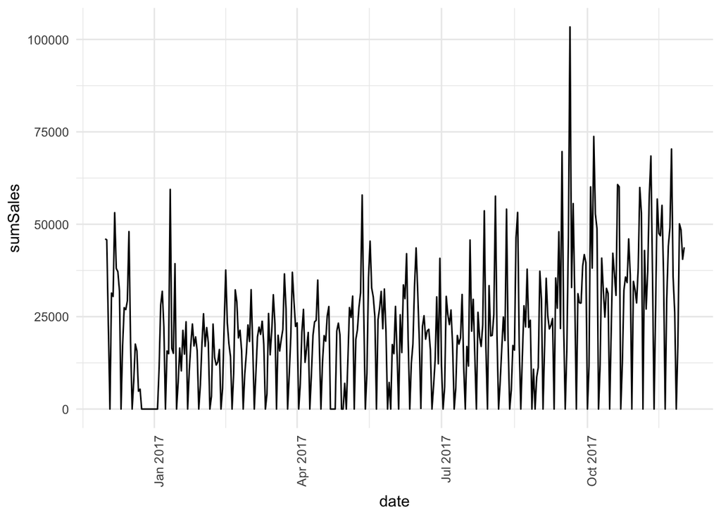

```r
data <- data %>%
  filter(date<=as.Date('2017-12-01'))

initialVisualization <- data %>%
  group_by(date) %>%
  summarise(sumSales = sum(sales))

ggplot(initialVisualization)+
  geom_line(aes(x=date,y=sumSales, group=1))+
  theme_minimal()+
  theme(axis.text.x = element_text(angle = 90, hjust = 1))
```

To better visualize and understand the data, we will change the timestamp and aggregate the sales column.

- Change the timestamp and aggregate the sales

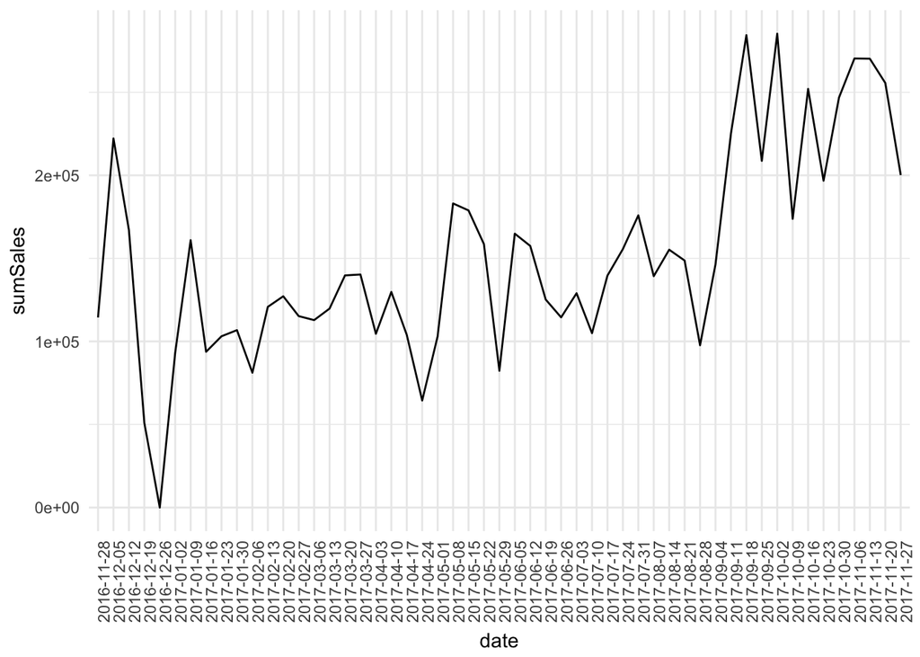

```r
Visualization1 <- data %>%
  group_by(date = cut(as.Date(date) ,'week'))%>%
  summarise(sumSales = sum(sales))

ggplot(Visualization1)+
  geom_line(aes(x=date,y=sumSales, group=1))+
  theme_minimal()+
  theme(axis.text.x = element_text(angle = 90, hjust = 1))
```

The previous chart suggests that we could apply a difference in order to eliminate the trend on the data over time. The ACF and PACF charts will confirm that.

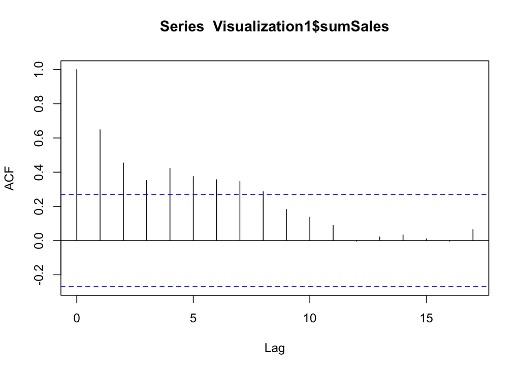

```r
acf(Visualization1$sumSales)
```

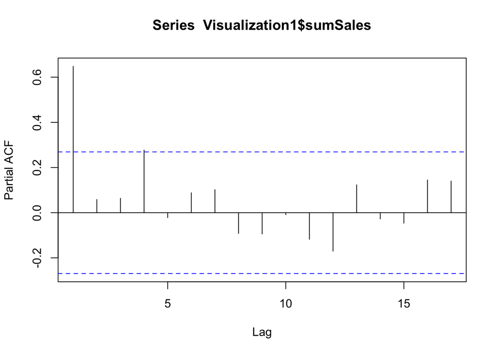

```r
pacf(Visualization1$sumSales)
```

Before going further and choosing the P and Q parameters of the ARIMA approach, we need to find out if it makes sense to model the average sale over the time. The following will show if this makes sense.

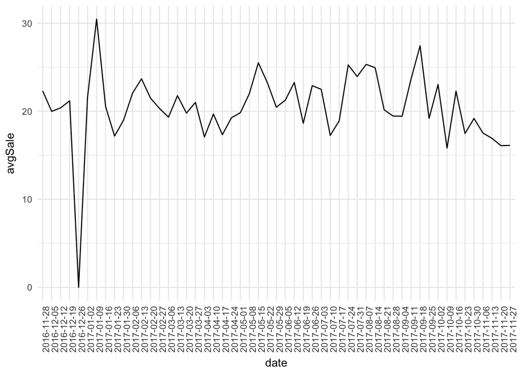

```r
ggplot(Visualization4)+
  geom_line(aes(x=date,y=avgSale, group=1))+
  theme_minimal()+
  theme(axis.text.x = element_text(angle = 90, hjust = 1))
```

So far, it seems that by performing transformations to the data we could model with ARIMA models the sales information. Before that, let us see if all the customers are similar in terms of amount of information, sales, and average sales.

# Data transformation and clusters

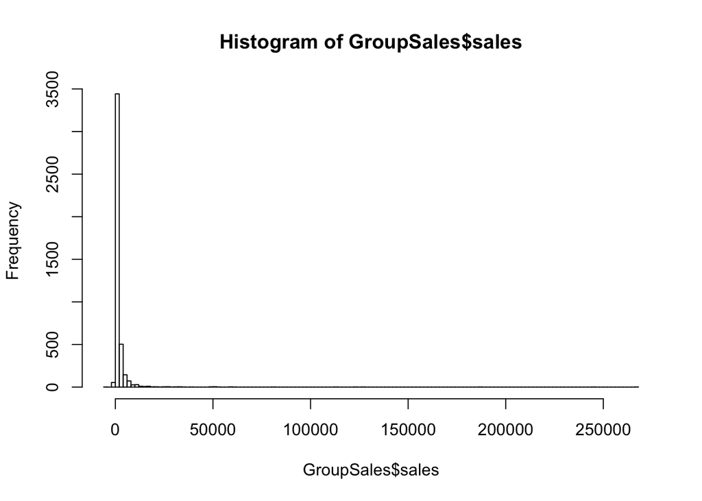

```r
GroupSales <- data %>%
  group_by(customer)%>%
  summarise(sales = sum(sales), count = n())%>%
  mutate(limitSales = ifelse((sales-mean(sales))/sd(sales)<=2.5, 1, 0))

hist(GroupSales$sales,breaks = 100)
```

```r
km <- kmeans(c(
  (GroupSales$sales - mean(GroupSales$sales))/sd(GroupSales$sales),
  (GroupSales$count - mean(GroupSales$count))/sd(GroupSales$count) ),5)
```

Where are we now? What next?

- Creating a unique model for the whole set of customers could lead to a wrong generalization and to a wrong forecast.
- We will create groups of clientes based on their sales levels and number of sales.

Firstly, we will split the customers in two, the ones that produce 27% of the sales and the ones that produce 73% of the sales.

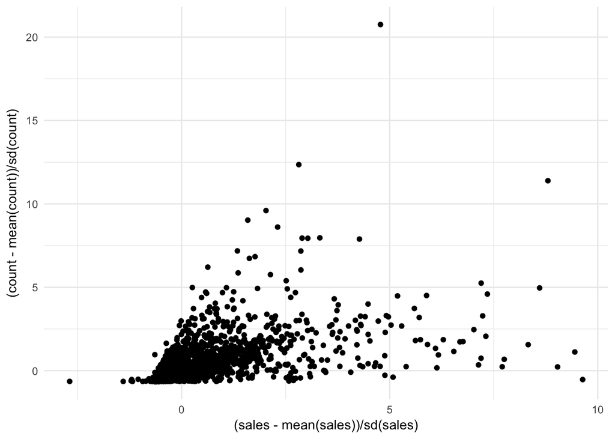

```r
GroupSales1 <- GroupSales %>%
  filter(limitSales==1)

GroupSales0 <- GroupSales %>%
  filter(limitSales==0)

ggplot(GroupSales1)+
  geom_point(aes( x=(sales-mean(sales))/sd(sales), y=(count-mean(count))/sd(count)))+
  theme_minimal()
```

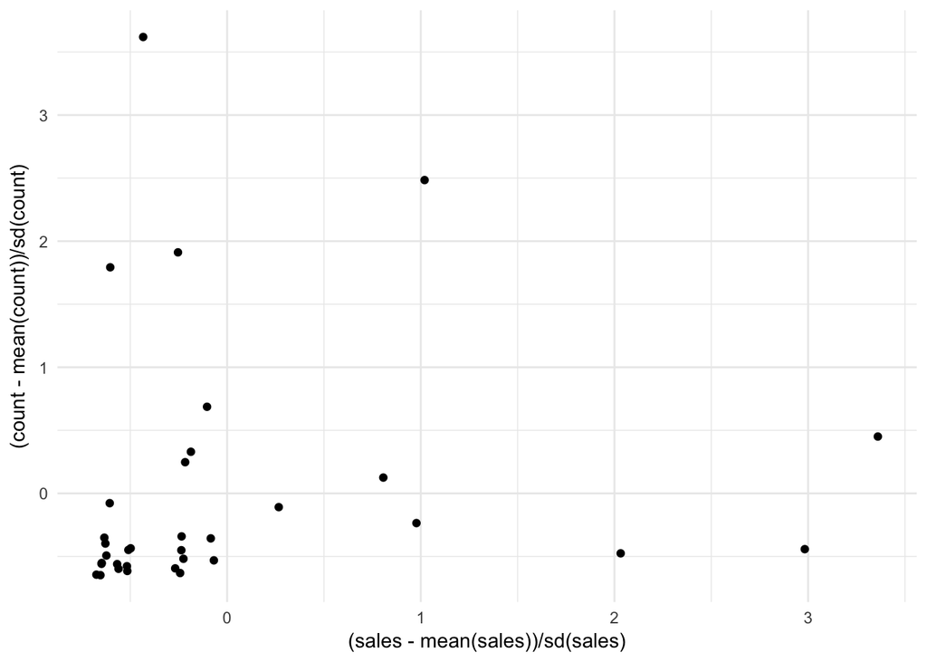

```r
ggplot(GroupSales0)+
  geom_point(aes( x=(sales-mean(sales))/sd(sales), y=(count-mean(count))/sd(count)))+
  theme_minimal()
```

Futhermore, we will use kmeans for creating clusters of customers and then create models to forecast the sales. This is how the clusters look like:

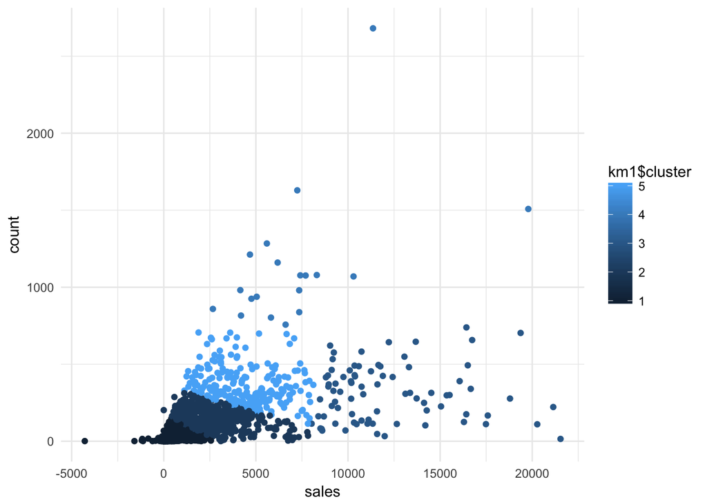

```r
gs1<- select(GroupSales1,sales,count)
gs1$sales<-(gs1$sales-mean(gs1$sales))/ sd(gs1$sales)
gs1$count<-(gs1$count-mean(gs1$count))/ sd(gs1$count)
km1 <- kmeans(gs1,5)
ggplot(GroupSales1, aes( x=sales, y=count, color=km1$cluster))+
  geom_point()+
  theme_minimal()
```

```r
GroupSales1<- GroupSales1 %>% add_column(cluster = km1$cluster)
gs1Dict <- GroupSales1 %>% select(customer,cluster)

custDict <- data %>%
  group_by(customer) %>%
  summarise(count = n())%>%
  select(customer)

custDict <- left_join( custDict , gs1Dict)
custDict$cluster <- ifelse(is.na(custDict$cluster),0,custDict$cluster)
```

# Sales forecasting

- Build an ARIMA model for every group of clients.
- Forecast sales of December 2017 based on the model from where the customer belongs to.

```r
ModelsByClst <- function(custDict, data){
  clModels <- list()
  for(i in 0:5){
    toTs <- custDict %>%
      filter(cluster == i) %>%
      left_join(data) %>%
      group_by(date = cut(as.Date(date) ,'week')) %>%
      summarise(sales = sum(sales), count_clients = n_distinct(customer) )%>%
      mutate(avgSales = sales/count_clients )%>%
      filter(as.Date(date) < as.Date('2017-12-01'))

    clTs <- xts(toTs$avgSales,as.Date(toTs$date))
    fit <- auto.arima(clTs)
    print(i)
    print(fit)
    clModels[[i+1]] <- fit
    }
  return(clModels)
}

mods <- ModelsByClst(custDict ,data)
```

```
## [1] 0
## Series: clTs
## ARIMA(0,1,1)
##
## Coefficients:
##           ma1
##       -0.8786
## s.e.   0.0673
##
## sigma^2 estimated as 1719430:  log likelihood=-438.72
## AIC=881.43   AICc=881.68   BIC=885.3
```

```
## [1] 1
## Series: clTs
## ARIMA(0,1,1)
##
## Coefficients:
##           ma1
##       -0.6856
## s.e.   0.1232
##
## sigma^2 estimated as 2417:  log likelihood=-276.15
## AIC=556.3   AICc=556.54   BIC=560.2
```

```
## [1] 2
## Series: clTs
## ARIMA(0,1,1)
##
## Coefficients:
##           ma1
##       -0.8523
## s.e.   0.0776
##
## sigma^2 estimated as 2779:  log likelihood=-274.72
## AIC=553.45   AICc=553.7   BIC=557.31
```

```
## [1] 3
## Series: clTs
## ARIMA(0,0,0) with non-zero mean
##
## Coefficients:
##           mean
##       719.7461
## s.e.   29.0371
##
## sigma^2 estimated as 44703:  log likelihood=-351.68
## AIC=707.37   AICc=707.61   BIC=711.27
```

```
## [1] 4
## Series: clTs
## ARIMA(0,0,1) with non-zero mean
##
## Coefficients:
##           ma1      mean
##       -0.2609  325.2691
## s.e.   0.1605   10.9416
##
## sigma^2 estimated as 11690:  log likelihood=-316.33
## AIC=638.66   AICc=639.16   BIC=644.51
```

```
## [1] 5
## Series: clTs
## ARIMA(1,0,0) with non-zero mean
##
## Coefficients:
##          ar1      mean
##       0.4397  396.1749
## s.e.  0.1329   15.9840
##
## sigma^2 estimated as 4437:  log likelihood=-291.22
## AIC=588.43   AICc=588.93   BIC=594.29
```

```r
dictDates <- as.data.frame(ymd("2016-12-01") + weeks(0:57))
colnames(dictDates)<-c("date")


ForDecSls <- function(custDict){
  CustList <- list()
  SlsList <- list()
  compData <- data.frame(customer = integer(), sales= integer())
  for (i in 1:length(custDict$customer)){
    nCustomer <- custDict$customer[i]
    nCluster <- custDict$cluster[i] +1

    toTs <- data %>%
      filter(customer == nCustomer) %>%
      group_by(date) %>%
      summarise(sales=sum(sales))

    toTs$date<-as.Date(as.character(toTs$date))

    toTs <- left_join(dictDates,toTs)

    toTs$sales <- ifelse(is.na(toTs$sales),0,toTs$sales)

    toTs <- toTs %>%
      group_by(date = cut(as.Date(date) ,'week')) %>%
      summarise(sales = sum(sales))%>%
      filter(as.Date(date) < as.Date('2017-12-01'))

    clTs <- xts(toTs$sales,as.Date(toTs$date))
    fit<-Arima(clTs,model = mods[[nCluster]])
    forSales<-forecast(fit, h=4)
    slsDec <- sum(forSales[4]$mean[1:4])

    compData <- rbind(compData,c(nCustomer, slsDec))

  }

  colnames(compData) <- c('Customer','SlsDecember')
  return(compData)

}
```

```r
View(DecemberSls)
```

[output not shown]